# Lab #12: Predicting Birth Weight

## Goals

- Practice assessing predictive ability of models
- Practice selecting among models using cross-validation
- Practice exploring model performance in a completely new data set

## Predicting Birth Weight

The relationship between gestational week and birth weight is not linear. For example, a typical fetus may weigh 150g at the end of 15 weeks of pregnancy, but in the latter weeks of pregnancy, the fetus may be gaining 150g or more per week. Thus polynomials like week$^2$, week$^3$, etc. are often used to model birth weight, in order to allow the rate of fetal weight gain to vary over the course of a pregnancy.

While polynomials are often a great way to model nuanced relationships, they are not without potential drawbacks. Sometimes people complain that they hamper interpretations of results, and while that may be true for individual coefficients, e.g. the parameter corresponding to week$^3$, it is always possible to graph a non-linear relationship, so that interpretability isn’t a big issue. Another potential problem is overfitting the data, especially near the lower and upper ends of the data range. You can see these effects in selected polynomial fits for boys and girls below (these are not adjusted for any other covariates or predictor variables, though estimates are stratified by sex in the plots).

```r
load("areabirths.RData")

library(tidyverse)
library(infer)
library(tidymodels)
library(kableExtra)
```

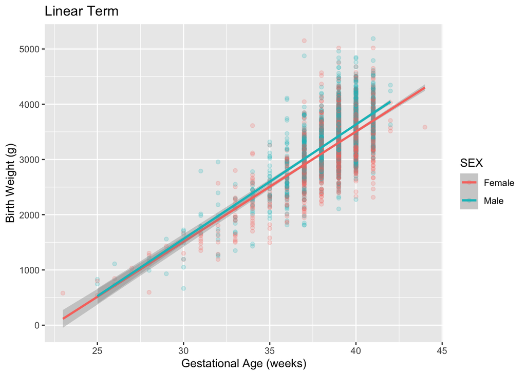

```r
m1plot <- durhambirth %>%
  ggplot(aes(x=GEST,y=BWTG,group=SEX)) +
  geom_point(aes(color=SEX),alpha=0.2) +
  stat_smooth(aes(color=SEX), method='lm',formula = y~poly(x,1)) +
  labs(title="Linear Term",
       x = "Gestational Age (weeks)",
       y = "Birth Weight (g)")

m5plot <- durhambirth %>%
  ggplot(aes(x=GEST,y=BWTG,group=SEX)) +
  geom_point(aes(color=SEX),alpha=0.2) +
  stat_smooth(aes(color=SEX), method='lm',formula = y~poly(x,5)) +
  labs(title="Fifth Order Polynomial",
       x = "Gestational Age (weeks)",
       y = "Birth Weight (g)")

m9plot <- durhambirth %>%
  ggplot(aes(x=GEST,y=BWTG,group=SEX)) +
  geom_point(aes(color=SEX),alpha=0.2) +
  stat_smooth(aes(color=SEX), method='lm',formula = y~poly(x,9)) +
  labs(title="Ninth Order Polynomial",
       x = "Gestational Age (weeks)",
       y = "Birth Weight (g)")

m1plot
```

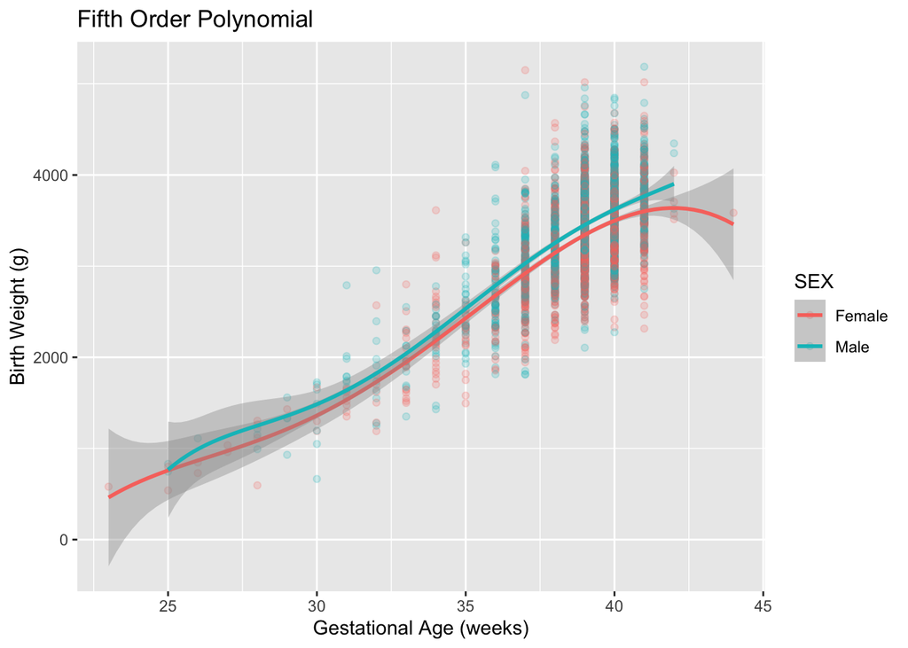

```r
m5plot
```